# tp_4_essai_python

### TP 4 : ABC et MH

## Partie I : ABC

1. (a) (b)

Pour cela, on tirera des $p$ sous le prior puis $X_1$ en fonction de $p$ jusqu'à tomber sur $X_1 = 1$ auquel cas on renvoie $p$

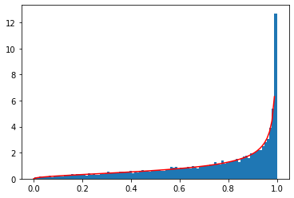

```python
import numpy as np
import matplotlib.pyplot as plt
from scipy.stats import beta
%matplotlib inline

def simul_1(a,b,x1):
    keep = False
    while not keep:
        p = np.random.beta(a,b)
        x1_sim =np.random.binomial(1,p)
        keep = (x1_sim==x1)
    return(p)


p_sim_post = [simul_1(1/2,1/2,1) for i in range(10000)]
plt.hist(p_sim_post,bins = 100,density = True)
pseq = np.linspace(0,1,100)
plt.plot(pseq,beta.pdf(pseq,1/2+1,1/2),color = "red")
```

2.

On peut tester en reprennant le code précédent, mais pour un échantillon.

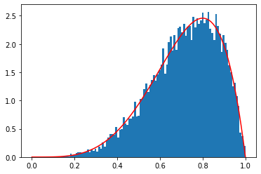

```python
def simul_1_bis(a,b,x1):
    keep = False
    while not keep:
        p = np.random.beta(a,b)
        x1_sim =np.random.binomial(1,p,len(x1))
        keep = np.prod(x1_sim==x1)
    return(p)

xobs = np.array([1,1,0,1,1,0,0,1,1,1,1,1,0,1,1,0,0,1,1,1])##trop long, on fait un test avec X plus petit
xobs = np.array([1,1,0,1,1])

p_sim_post = [simul_1_bis(1,1,np.array(xobs)) for i in range(10000)]
plt.hist(p_sim_post,bins = 100,density = True)
pseq = np.linspace(0,1,100)
plt.plot(pseq,beta.pdf(pseq,1+np.sum(xobs),1+np.sum(1-xobs)),color = "red")
```

Bon, déjà, c'est bien long pour $n = 5$, alors pour de très nombreuses observations, ça va devenir compliqué.

1. 4. On reprend encore le code précédent, mais cette fois, en changeant la condition d'arrêt, utilisant la stat exhaustive $S_n$. (en effet, c'est à cause de cette propriété que l'on peut écrire que le postérior correspond a
   $$\pi(p \mid S_n)$$

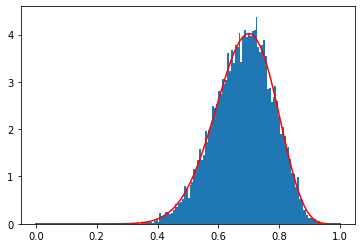

```python
def simul_2(a,b,n,s):
    keep = False
    while not keep:
        p = np.random.beta(a,b)
        s_sim =np.random.binomial(n,p,1)
        keep = (s_sim==s)
    return(p)

xobs = np.array([1,1,0,1,1,0,0,1,1,1,1,1,0,1,1,0,0,1,1,1])##trop long, on fait un test avec X plus petit
# xobs = np.array([1,1,0,1,1])

p_sim_post = [simul_2(1,1,len(xobs),np.sum(xobs)) for i in range(10000)]
plt.hist(p_sim_post,bins = 100,density = True)
pseq = np.linspace(0,1,100)
plt.plot(pseq,beta.pdf(pseq,1+np.sum(xobs),1+np.sum(1-xobs)),color = "red")
```

Ok, ça marche bien mais on se rend compte que dès que l'on va avoir de très nombreuses observations, cela risque de ramer un max aussi.

1. On adapte encore le code

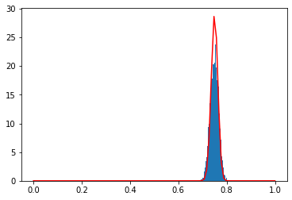

```python
def rsimABC(a,b,n,s,epsilon):
    keep = False
    while not keep:
        p = np.random.beta(a,b)
        s_sim =np.random.binomial(n,p,1)
        keep = (np.abs(s_sim-s)<epsilon)
    return(p)


p_sim_post = [rsimABC(1,1,1000,750,20) for i in range(10000)]
plt.hist(p_sim_post,bins = 100,density = True)
pseq = np.linspace(0,1,100)
plt.plot(pseq,beta.pdf(pseq,1+750,1+250),color = "red")
```

On voit déjà l'erreur d'appoximation que l'on fait (on peut s'amuser à changer $\epsilon$ pour voir la différence). Cela motive pas mal la partie suivante : un algorithme de simulation exacte !

## Partie II : Metropolis Hasting

```python
def rmix(n,par):
    """ Simule un mélange Gaussien
    Parameters :
    n : Int
        Taille du vecteur simulé
    par : dict with m (vectors of mean),tau (vector of precision), p (class importances)
    """
    b = np.random.binomial(1,par["p"],size = n)
    x0 = np.random.normal(par["m"][0],1/np.sqrt(par["tau"][0]),size = n)
    x1 = np.random.normal(par["m"][1],1/np.sqrt(par["tau"][1]),size = n)
    z = (1-b)*x0+b*x1
    return(z)
```

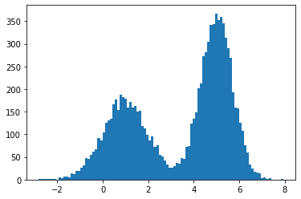

```python
par = {"m" :np.array([1,5]),"tau":np.array([1,2]),"p":0.6}
z = rmix(10000,par)
plt.figure()
plt.hist(z,bins = 100)
plt.show()
```

1. C'est parti pour l'écriture de toutes les fonctions !!

```python
from scipy.stats import norm
def logvraiss(x,par):
    veclogvraiss = np.log( (1-par["p"])*norm.pdf(x,par["m"][0],1/par["tau"][0])
                          +(par["p"])*norm.pdf(x,par["m"][1],1/par["tau"][1])         )
    return(np.sum(veclogvraiss))


logvraiss(z,par)
```

```
-19373.97665939162
```

1. Idem pour le prior

```python
from scipy.stats import beta
from scipy.stats import gamma

def logprior(par,hyp):
    prior_p = beta.logpdf(par["p"],hyp["a0"],hyp["b0"])
    prior_m = norm.logpdf(par["m"],hyp["mu0"],hyp["sig0"])
    prior_tau = gamma.logpdf(par["tau"],hyp["k0"],scale = hyp["lam0"])
    return(prior_p+np.sum(prior_m)+np.sum(prior_tau))


hyp = {"a0":1/2,"b0":1/2,"mu0":0,"sig0":1,"k0":1,"lam0":1}
logprior(par,hyp)
```

```
-18.269048774438673
```

1. On n'a plus qu'à faire la somme !

```python
def logpost(x,par,hyp):
    return(logvraiss(x,par)+logprior(par,hyp))

logpost(z,par,hyp)
```

```
-19392.24570816606
```

1. Bon, ça c'est le moment bien pénible !!! On va pour le moment faire une loi de proposition pour tous les paramètres en même temps, mais cela pourrait être intélligent d'en faire un par paramètre (on pourra le voir dans une version où la variable de mélange est explicitée).

```python
def rprop(par,prop_par,opt = "m"):
    """Propose une modification des paramètres p,m,tau, et calcule le ratio des lois de propositions"""
    logratio = 0#On garde en mémoire le log du ratio des densité pour MH
    p = par["p"]
    m = par["m"]
    tau = par["tau"]
    if opt == "all" or opt=="p":
        p = np.random.beta(1+par["p"]/prop_par["sigp"],1+(1-par["p"])/prop_par["sigp"]   )
        logratio+=(beta.logpdf(par["p"],1+p/prop_par["sigp"],1+(1-p)/prop_par["sigp"]   )
                   -  beta.logpdf(p,1+par["p"]/prop_par["sigp"],1+(1-par["p"])/prop_par["sigp"]  ) )
    if opt == "all" or opt=="m":
        m = np.random.normal(par["m"],prop_par["sigm"] )
    if opt == "all" or opt=="tau":
        tau = np.random.gamma(par["tau"]/prop_par["sigtau"],prop_par["sigtau"])
        logratio+=np.sum( gamma.logpdf(par["tau"],tau/prop_par["sigtau"],scale = prop_par["sigtau"])-
                    gamma.logpdf(tau,par["tau"]/prop_par["sigtau"],scale = prop_par["sigtau"]) )
    ##on change l'ordre pour garder l'identifiablité
    if m[0]>m[1]:
        m = np.flip(m)
        tau = np.flip(tau)
        p = 1-p
    return({"p":p,"m":m,"tau":tau},logratio)



print(par)
prop_par = {"sigp":0.000001,"sigm":0.1,"sigtau":0.01}
rprop(par,prop_par)
```

```
{'m': array([1, 5]), 'tau': array([1, 2]), 'p': 0.6}
```

```
({'p': 0.6, 'm': array([0.98172522, 5.27107945]), 'tau': array([1, 2])}, 0)
```

1. C'est parti pour la partie marrante !

```python
def stepMH(x,par,hyp,prop_par):
    """Réalise une étape de MH"""
    ##On propose
    opt = ["p","m","tau"][int(3*np.random.uniform())]
#     opt = "m"
    prop,logratio = rprop(par,prop_par,opt = opt)
    ## on calcule le log de la proba d'acceptation attention au -infini
    logalpha =logratio+logpost(x,prop,hyp)-logpost(x,par,hyp)
#     print(logalpha)
    if np.log(np.random.uniform())<logalpha:
        accept = True
        new_par = prop
    else:
        accept = False
        new_par = par
    return(new_par,accept)

for i in range(4):
    print(stepMH(z,par,hyp,prop_par))
```

```
({'p': 0.6, 'm': array([1, 5]), 'tau': array([1.08516843, 1.88784425])}, True)
({'p': 0.6, 'm': array([1, 5]), 'tau': array([1.06474132, 1.81338921])}, True)
({'m': array([1, 5]), 'tau': array([1, 2]), 'p': 0.6}, False)
({'p': 0.6, 'm': array([0.93910952, 5.07614504]), 'tau': array([1, 2])}, True)
```

```python
def init_par(z):
        return({"m" : np.array([np.mean(z),np.mean(z)]),
            "tau" : np.array([1/np.var(z),1/np.var(z)]),"p":1/2})
#     return({"m" : np.array([np.mean(z)-np.sqrt(np.var(z)),np.mean(z)+np.sqrt(np.var(z))]),
#             "tau" : np.array([1/np.var(z),1/np.var(z)]),"p":1/2})
#     return({"m" : np.array([np.mean(z)-np.sqrt(np.var(z)),np.mean(z)+np.sqrt(np.var(z))]),
#             "tau" : np.array([1,2]),"p":1/2})
```

1. Et c'est parti

```python
def run_MH(x,nbstep,prop_par):
    par = init_par(x)
    mem = []
    ac_mem = []
    for i in range(nbstep):
        par,accept  = stepMH(x,par,hyp,prop_par)
        mem.append(list(par["m"])+list(par["tau"])+[par["p"]])
        ac_mem.append(accept)
    return(np.array(mem),np.array(ac_mem))


run_MH(x,10,prop_par)
```

```
(array([[2.63600572, 2.63600572, 0.21450956, 0.21450956, 0.5       ],
        [2.63600572, 2.63600572, 0.18708324, 0.25579762, 0.5       ],
        [2.63600572, 2.63600572, 0.1794717 , 0.28248161, 0.5       ],
        [2.63600572, 2.63600572, 0.1794717 , 0.28248161, 0.56387561],
        [2.63600572, 2.63600572, 0.1794717 , 0.28248161, 0.56387561],
        [2.63600572, 2.63600572, 0.1794717 , 0.28248161, 0.56387561],
        [2.63600572, 2.63600572, 0.1794717 , 0.28248161, 0.56387561],
        [2.63600572, 2.63600572, 0.1794717 , 0.28248161, 0.56387561],
        [2.63600572, 2.63600572, 0.1794717 , 0.28248161, 0.58058585],
        [2.63600572, 2.63600572, 0.1794717 , 0.28248161, 0.58058585]]),
 array([False,  True,  True,  True, False, False, False, False,  True,
        False]))
```

1. On peut commencer à observer les résultats obtenus

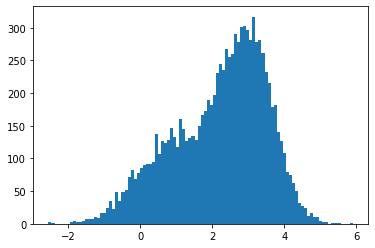

```python
partrue = {"m" :np.array([1,3]),"tau":np.array([1,2]),"p":0.6}
z = rmix(10000,partrue)
plt.figure()
plt.hist(z,bins = 100)
plt.show()
prop_par = {"sigp":0.01,"sigm":0.1,"sigtau":0.01}
```

```python
mem,ac_mem = run_MH(z,20000,prop_par)
print(mem[-1,:])
chauff = 100
plt.figure()
plt.plot(mem[chauff:,0])
plt.plot(mem[chauff:,1],color = "red")
plt.show()
print("Pourcentage d'acceptation : ",np.mean(ac_mem))
```

[output not shown]

```python
plt.figure()
plt.plot(mem[chauff:,4])
plt.show()
```

[output not shown]

```python
fig,ax = plt.subplots()
ax.hist(mem[chauff:,0],bins = np.linspace(0.8,1.2,100))
plt.show()
```

[output not shown]

A vous de jouer pour faire plein de trucs avec ce posterior, et pour changer les paramètres du mélange simulé, ainsi que les variances des lois de propositions, pour voir ce qu'il se passe !